# Dirty Data Final Project

Nicholas Redmond

1/16/2021

## COVID-19 Mortality Across Nine Different Countries

I retrieved this data from https://ourworldindata.org/coronavirus-source-data

### Motivation

Some questions this projects aim to answer is how COVID-19 spreads among populations among different countries of different development statuses and with different gross domestic products, life expectancies, and median ages. The goal of this analysis is to find a correlation among spread in wealthy, well-developed countries versus poorer countries and to try and find a correlation with deaths among generally older populations versus generally younger populations, as there are multiple claims the COVID-19 is deadlier for elderly populations.

### Coding

With this data, any columns with inexplicable missing data were removed from the dataframe. There were 33 columns with inexplicable missing data, so out of 54 variables, 21 of them were retained for the analysis. There was a lot of missing data in the early dates for each country, but those missing values were from before the country started tracking Coronavirus cases, so I recoded them to be 0 using: final.covid.data[is.na(final.covid.data)] = 0

### Analysis

My first table compares latest total case count per million people to population density.

|  | total_cases_per_million | population_density |
| --- | --- | --- |
| **317** | 1364 | 54.42 |
| **668** | 37087 | 16.18 |
| **1015** | 1119 | 3.202 |
| **1331** | 37043 | 25.04 |
| **1682** | 66.97 | 147.7 |
| **2054** | 11478 | 66.44 |
| **2368** | 457.8 | 209.6 |
| **2703** | 19383 | 46.75 |
| **3054** | 64348 | 35.61 |

However, this correlation (or lack thereof) would best be represented in a plot

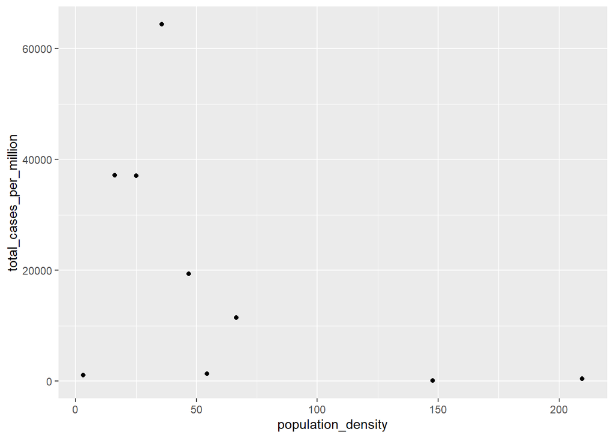

It appears there may be a slight correlation between lower population density and higher case count per million.

Next, we look at how each country tracked their case counts over the duration of the pandemic so far.

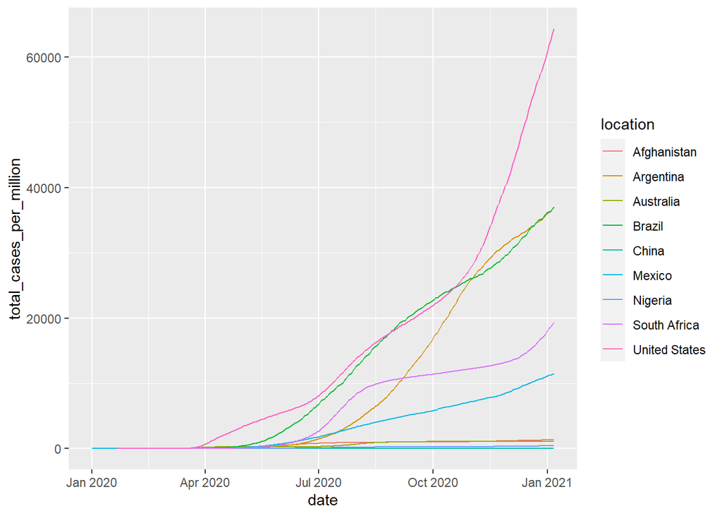

It appears that some countries either slowed the pandemic’s spread very quickly, or did not track the virus very well, the latter of which is more plausible.

We now look at markers of development versus total deaths and cases.

Table continues below

|  | location | total_cases | total_deaths |
| --- | --- | --- | --- |
| **317** | Afghanistan | 53105 | 2244 |
| **668** | Argentina | 1676171 | 43976 |
| **1015** | Australia | 28546 | 909 |
| **1331** | Brazil | 7873830 | 198974 |
| **1682** | China | 96398 | 4788 |
| **2054** | Mexico | 1479835 | 129987 |
| **2368** | Nigeria | 94369 | 1324 |
| **2703** | South Africa | 1149591 | 31368 |
| **3054** | United States | 21299340 | 361123 |

|  | human_development_index | life_expectancy | gdp_per_capita |
| --- | --- | --- | --- |
| **317** | 0.498 | 64.83 | 1804 |
| **668** | 0.825 | 76.67 | 18934 |
| **1015** | 0.939 | 83.44 | 44649 |
| **1331** | 0.759 | 75.88 | 14103 |
| **1682** | 0.752 | 76.91 | 15309 |
| **2054** | 0.774 | 75.05 | 17336 |
| **2368** | 0.532 | 54.69 | 5338 |
| **2703** | 0.699 | 64.13 | 12295 |
| **3054** | 0.924 | 78.86 | 54225 |

A country that is an outlier that most likely tracked cases well is Australia. Most recently, they had only recorded 909 deaths, which indicates an exceptional job at controlling COVID-19.

Finally, we look at the correlation between median age and total most recent death count per million people.

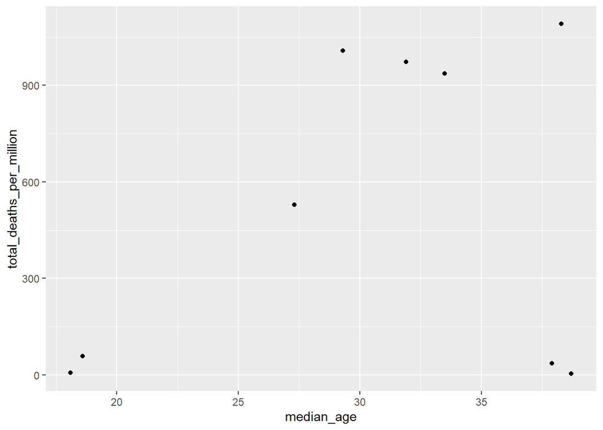